# STA6856 Time Series

## 7. Diagnostic check of the residuals from the SARIMA models being fitted.

### Autofit

```
Null hypothesis: Residuals are iid noise.
Test                        Distribution Statistic   p-value
Ljung-Box Q                Q ~ chisq(20)     15.28    0.7602
McLeod-Li Q                Q ~ chisq(20)     19.91    0.4638
Turning points T  (T-247.3)/8.1 ~ N(0,1)       247    0.9673
Diff signs S        (S-186)/5.6 ~ N(0,1)       180    0.2825
Rank P           (P-34689)/1203 ~ N(0,1)     35665    0.4172
```

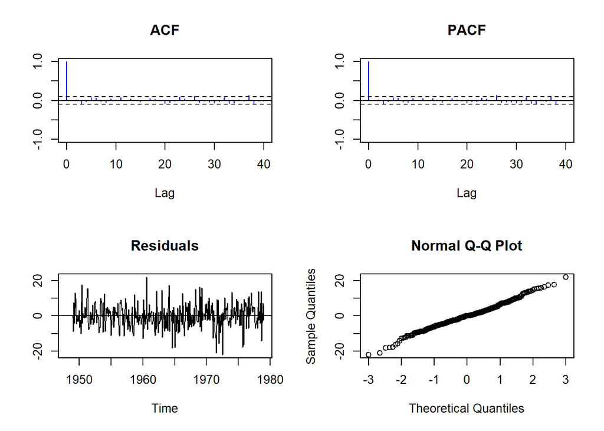

```r
# autofit
test(birth_bestmodel$residuals)
```

```r
confint(birth_bestmodel)
```

```
           2.5 %      97.5 %
ma1  -0.49865588 -0.29806967
ma2  -0.25837278 -0.06799309
sar1 -0.03800006  0.24162021
sma1 -0.93673412 -0.75006425
```

### Fit 1

```
Null hypothesis: Residuals are iid noise.
Test                        Distribution Statistic   p-value
Ljung-Box Q                Q ~ chisq(20)       7.4    0.9952
McLeod-Li Q                Q ~ chisq(20)     17.47    0.6223
Turning points T  (T-247.3)/8.1 ~ N(0,1)       245    0.7739
Diff signs S        (S-186)/5.6 ~ N(0,1)       177    0.1069
Rank P           (P-34689)/1203 ~ N(0,1)     35504    0.4981
```

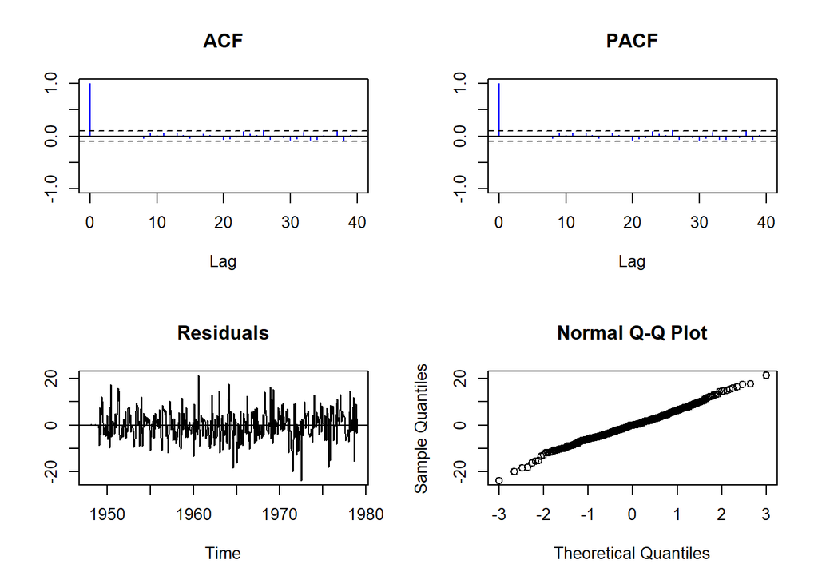

```r
# SARIMA (7,1,1)x(1,1,1)12
test(birth_fit1$residuals)
```

```r
confint(birth_fit1)
```

```
           2.5 %      97.5 %
ar1  -0.82065637  1.03516913
ar2  -0.46838234  0.28107416
ar3  -0.39929802  0.17429866
ar4  -0.31194757  0.20207399
ar5  -0.13430329  0.25527025
ar6  -0.06991763  0.15348890
ar7  -0.16788816  0.05144479
ma1  -1.41980919  0.42709079
sar1 -0.04846382  0.23064707
sma1 -0.93777281 -0.75488435
```

### Fit 2

```
Null hypothesis: Residuals are iid noise.
Test                        Distribution Statistic   p-value
Ljung-Box Q                Q ~ chisq(20)      3.52         1
McLeod-Li Q                Q ~ chisq(20)     20.86    0.4057
Turning points T  (T-247.3)/8.1 ~ N(0,1)       243    0.5937
Diff signs S        (S-186)/5.6 ~ N(0,1)       176    0.0733
Rank P           (P-34689)/1203 ~ N(0,1)     35443    0.5308
```

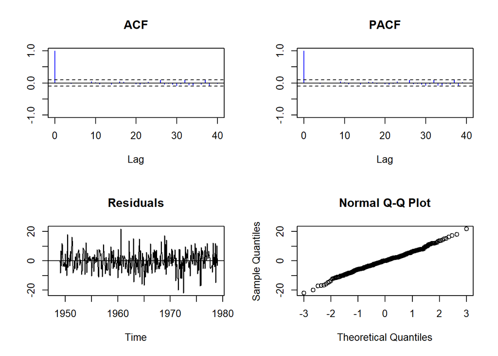

```r
# SARIMA (14,1,1)x(2,1,1)12
test(birth_fit2$residuals)
```

```r
confint(birth_fit2)
```

```
           2.5 %      97.5 %
ar1  -0.22628150  0.50507132
ar2  -0.24986010  0.09439870
ar3  -0.22220650  0.01156562
ar4  -0.15842565  0.07917427
ar5  -0.04136492  0.17845918
ar6  -0.07179113  0.14015561
ar7  -0.15691607  0.04190122
ar8  -0.15738331  0.04994228
ar9  -0.08240059  0.13523431
ar10 -0.10129591  0.09810927
ar11 -0.02022842  0.18440205
ar12  0.16702093  0.70530710
ar13 -0.19446488  0.21009138
ar14 -0.04661836  0.24800370
ma1  -0.88542792 -0.16757650
sar1 -0.56006808 -0.07195063
sar2 -0.23915844  0.11449779
sma1 -1.01732748 -0.81025300
```

### Fit 3

```
Null hypothesis: Residuals are iid noise.
Test                        Distribution Statistic   p-value
Ljung-Box Q                Q ~ chisq(20)      8.28    0.9898
McLeod-Li Q                Q ~ chisq(20)      17.8    0.6007
Turning points T  (T-247.3)/8.1 ~ N(0,1)       245    0.7739
Diff signs S        (S-186)/5.6 ~ N(0,1)       178    0.1519
Rank P           (P-34689)/1203 ~ N(0,1)     35475    0.5135
```

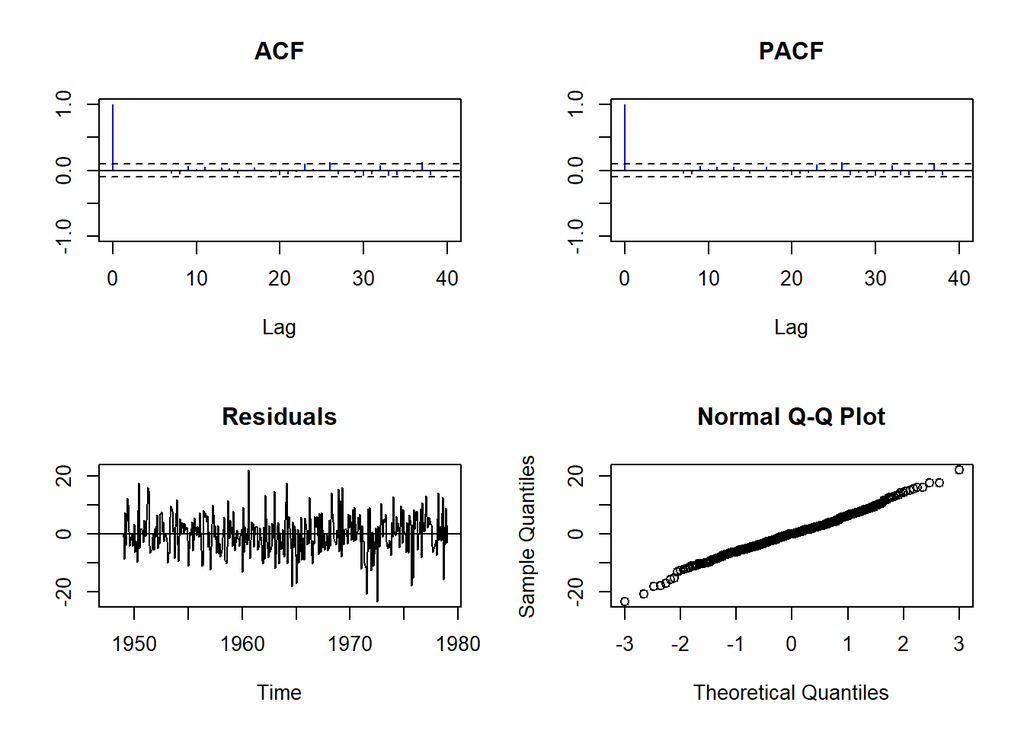

```r
# SARIMA (5,1,1)x(2,1,1)12
test(birth_fit3$residuals)
```

```r
confint(birth_fit3)
```

```
           2.5 %      97.5 %
ar1  -1.73199717  0.18737484
ar2  -0.83709605 -0.05982978
ar3  -0.67751560 -0.07154295
ar4  -0.54978765 -0.01504383
ar5  -0.28703155  0.07486742
ma1  -0.57979882  1.33661988
sar1 -0.03856579  0.25450912
sar2 -0.09339297  0.17633528
sma1 -0.96877263 -0.75940508
```

### Fit 4

```
Null hypothesis: Residuals are iid noise.
Test                        Distribution Statistic   p-value
Ljung-Box Q                Q ~ chisq(20)      4.32    0.9999
McLeod-Li Q                Q ~ chisq(20)     19.27    0.5047
Turning points T  (T-247.3)/8.1 ~ N(0,1)       247    0.9673
Diff signs S        (S-186)/5.6 ~ N(0,1)       176    0.0733
Rank P           (P-34689)/1203 ~ N(0,1)     35498    0.5013
```

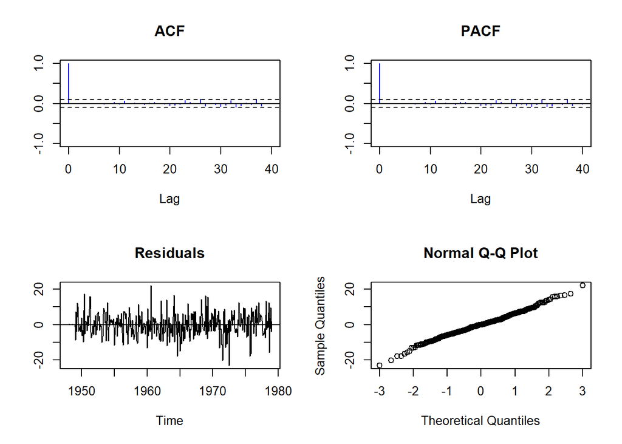

```r
# SARIMA (5,1,5)x(1,1,2)12
test(birth_fit4$residuals)
```

```r
confint(birth_fit4)
```

```
           2.5 %     97.5 %
ar1  -2.08910529  1.0511829
ar2  -1.54254191  0.4560469
ar3  -1.59568314  0.2344836
ar4  -1.09921790  1.4151756
ar5  -0.46778275  0.1628916
ma1  -1.44657387  1.7027817
ma2  -0.23306084  0.6399813
ma3  -0.06406656  0.7092596
ma4  -1.26058161  0.1168323
ma5  -0.78375317  1.1454152
sar1 -0.54978818  1.3062085
sma1 -2.03647014 -0.1422006
sma2 -0.54388501  0.9489838
```

### Fit 5

```
Null hypothesis: Residuals are iid noise.
Test                        Distribution Statistic   p-value
Ljung-Box Q                Q ~ chisq(20)     14.64    0.7965
McLeod-Li Q                Q ~ chisq(20)     21.18    0.3866
Turning points T  (T-247.3)/8.1 ~ N(0,1)       247    0.9673
Diff signs S        (S-186)/5.6 ~ N(0,1)       177    0.1069
Rank P           (P-34689)/1203 ~ N(0,1)     35392     0.559
```

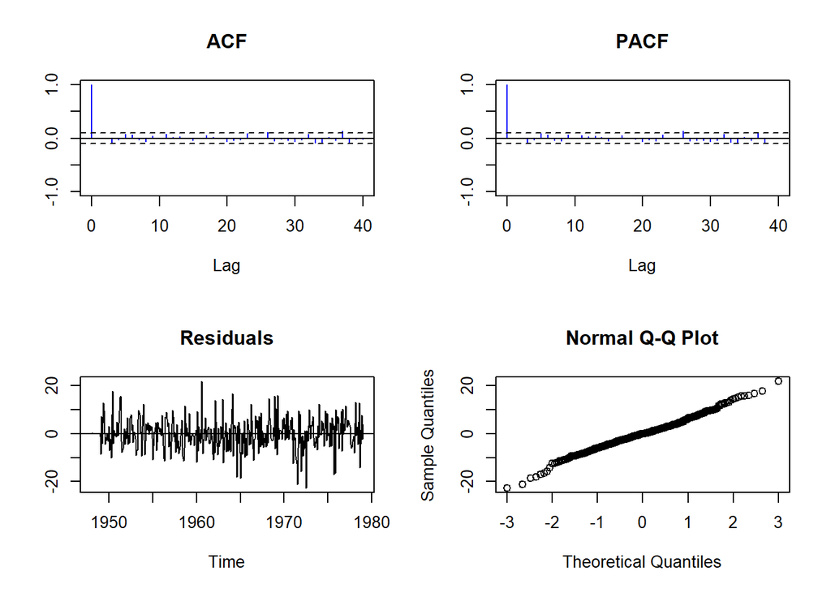

```r
# SARIMA (0,1,2)x(1,1,2)12
test(birth_fit5$residuals)
```

```r
confint(birth_fit5)
```

```
          2.5 %      97.5 %
ma1  -0.5025540 -0.30144149
ma2  -0.2579715 -0.06698235
sar1  0.6845752  1.04945159
sma1 -1.9224890 -1.40096638
sma2  0.4231010  0.90038906
```

## 8. Select a final SARIMA model and type its equation.

```r
# Comparison
AIC.values = c(
  automodel = birth_bestmodel$aic,
  fit1 = birth_fit1$aic,
  fit2 = birth_fit2$aic,
  fit3 = birth_fit3$aic,
  fit4 = birth_fit4$aic,
  fit5 = birth_fit5$aic
)
AIC.values
```

```
automodel      fit1      fit2      fit3      fit4      fit5
 2419.863  2424.077  2431.206  2422.691  2427.099  2420.430
```

- The best model is the auto-fit model.
- SARIMA (0,1,2)x(1,1,1)12

  $$(B)(1-0.1018B^{12})(1-B)X_t= (1 + 0.3984B + 0.1632B^2)(1+0.8434^{12})(1-B)Z_t \quad Z_t \sim WN(0, 46.1)$$

## 9. Split data to two data sets: training (367 obs.) and testing (the most recent/last 6 obs.)

```r
# Training Split
birth_training = birth[1:367]

# Creating a time series
birth_training_ts = ts(birth_training,start=1,frequency = 12)
```

## 10. Fit a SARIMA model to the training series and forecast the next 6 observations.

```r
# SARIMA (7,1,1)x(1,1,1)12
fit1_forecast = arima(birth_training,
            order = c(7,1,1),
            seasonal = list(order=c(1,1,1),period=12))

# SARIMA (0,1,2)x(1,1,1)12
fit2_forecast  = arima(birth_training,
            order = c(0,1,2),
            seasonal = list(order=c(1,1,1),period=12))

# SARIMA (5,1,1)x(2,1,1)12
fit3_forecast  = arima(birth_training,
            order = c(5,1,1),
            seasonal = list(order=c(2,1,1),period=12))

# SARIMA (5,1,5)x(1,1,2)12
fit4_forecast  = arima(birth_training,
            order = c(5,1,5),
            seasonal = list(order=c(1,1,2),period=12))

# SARIMA (0,1,1)x(1,1,2)12
fit5_forecast  = arima(birth_training,
            order = c(0,1,2),
            seasonal = list(order=c(1,1,2),period=12))

# Auto fit
automodel_forecast  = auto.arima(birth_training, trace= T, seasonal = T)
```

```
 Fitting models using approximations to speed things up...

 ARIMA(2,1,2) with drift         : Inf
 ARIMA(0,1,0) with drift         : 3111.373
 ARIMA(1,1,0) with drift         : 3073.474
 ARIMA(0,1,1) with drift         : 3079.07
 ARIMA(0,1,0)                    : 3109.351
 ARIMA(2,1,0) with drift         : 3074.167
 ARIMA(1,1,1) with drift         : 3073.865
 ARIMA(2,1,1) with drift         : 3076.166
 ARIMA(1,1,0)                    : 3071.441
 ARIMA(2,1,0)                    : 3072.123
 ARIMA(1,1,1)                    : 3071.82
 ARIMA(0,1,1)                    : 3077.038
 ARIMA(2,1,1)                    : 3074.111

 Now re-fitting the best model(s) without approximations...

 ARIMA(1,1,0)                    : 3076.499

 Best model: ARIMA(1,1,0)
```

```r
# Autofit arima
bestmodel_forecast = arima(birth_training, order = c(1,1,0))
# Autofit forecast
f.auto = aTSA::forecast(object = bestmodel_forecast,lead = 6, output = FALSE)
```

```r
f1 = aTSA::forecast(object = fit1_forecast,lead = 6,output = FALSE)
f2  = aTSA::forecast(object = fit2_forecast,lead = 6,output = FALSE)
f3  = aTSA::forecast(object = fit3_forecast,lead = 6,output = FALSE)
f4  = aTSA::forecast(object = fit4_forecast,lead = 6,output = FALSE)
f5  = aTSA::forecast(object = fit5_forecast,lead = 6,output = FALSE)
```

## 11. Run ARAR and Holt-Winters algorithms to predict the same number of observations.

```
Optimal lags 1 5 12 13
Optimal coeffs 0.6915158 0.1986235 -0.4050149 0.3325551
WN Variance 56.76254
Filter 1 -0.6915158 0 0 0 -0.1986235 0 0 0 0 0 0 -0.5922443 0.3570654 0 0 0 0.1980791 0 0 0 0 0 0 -0.4039049 0.3316437

 Step     Prediction      sqrt(MSE)    Lower Bound    Upper Bound
    1        295.009       7.534092       280.2422       309.7759
    2       293.7553       9.160025       275.8017        311.709
    3       284.0187       9.843065       264.7263       303.3112
    4        262.488       10.15346       242.5872       282.3888
    5       274.4614       10.29859       254.2762       294.6466
    6       267.2295       10.64355       246.3681       288.0909
```

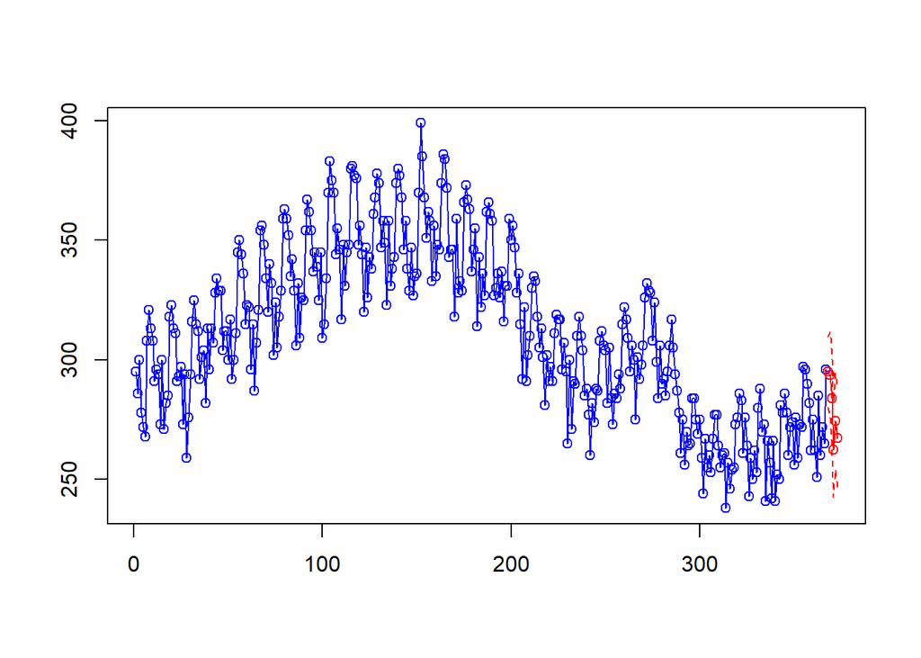

```r
# ARAR
arar.prd = arar(birth_training, h=6)
```

```r
# Holt-Winters
HWmodel = HoltWinters(birth_training_ts,seasonal = "mult")
HW.prd =forecast::forecast(HWmodel,6)
```

## 12. Compare the models in terms of MAPE.

```r
library(Metrics)
MAPE1 = mape(birth[368:373],f1[,2])*100
MAPE2 = mape(birth[368:373],f2[,2])*100
MAPE3 = mape(birth[368:373],f3[,2])*100
MAPE4 = mape(birth[368:373],f4[,2])*100
MAPE5 = mape(birth[368:373],f5[,2])*100
MAPEauto = mape(birth[368:373],f.auto[,2])*100
MAPEarar = mape(birth[368:373],arar.prd$pred)*100
MAPEhw = mape(birth[368:373],HW.prd$mean)*100


MAPEs = c(fit1_mape = MAPE1,
          fit2_mape = MAPE2,
          fit3_mape = MAPE3,
          fit4_mape = MAPE4,
          fit5_mape = MAPE5,
          fitauto_mape = MAPEauto,
          arar.model = MAPEarar,
          hw.model = MAPEhw)
MAPEs
```

```
   fit1_mape    fit2_mape    fit3_mape    fit4_mape    fit5_mape fitauto_mape
    2.084180     2.076262     2.110923     2.109824     2.011246     3.771297
  arar.model     hw.model
    2.977125     2.203462
```

- Fit5 (0,1,2)x(1,1,2)x12 has the lowest Mean Absolute Percent Error, MAPE = 2.011.